# Домашнее задание 3 по прикладной эконометрике

Московский Государственный Университет им. М.В. Ломоносова Экономический факультет Кафедра Финансов и Кредита

Хейфец Владислава (э404) Чиркизьянова Виктория (э404)

27 ноября 2024 года

Москва 23.12.2024

# Оценка эффекта методом «разность разностей»

## Задание 1

Рисунок 2(а) показывает среднее недельное значение цены отеля в Корсике и в Сардинии на двоих в 2015 году. График 2(b) показывает ежемесячное количество прибывающих в аэропорты исследуемых регионов за 2014-2016 годы. Вертикальными линиями обозначаются моменты принятия (28-я неделя 2015 года, пунктирная линия) и обнародования (32-я неделя 2015 года, сплошная линия) закона Макрона.

Данный рисунок был приведен авторами для демонстрации того, что уровень цен на отели напрямую зависит от сезона и имеет значительные отличия в разные периоды времени, не связанные с влиянием исследуемого события. Таким образом, авторы показывают, что в данных присутствует очевидный тренд, который стоит учесть при дальнейшем анализе.

### Установка библиотек

```r
# install.packages("haven")
# install.packages("dplyr")
# install.packages("lmtest")
# install.packages("stargazer")
# install.packages("Synth")
# install.packages("gsynth")

library(haven)
library(dplyr)
library(lmtest)
library(stargazer)
library("Synth")
library("gsynth")
```

### Загрузка данных

```r
data_task_1 <- read_dta("data/data_mac_sr.dta") %>% filter(sample_mac_sr == 1)
head(data_task_1, 2)
```

```
## # A tibble: 2 × 39
##   urlnum        datein     month  week   day  year date_src   bmonth bweek byear
##   <dbl+lbl>     <date>     <dbl> <dbl> <dbl> <dbl> <date>      <dbl> <dbl> <dbl>
## 1 1765 [/hotel… 2015-09-01     9    35     1  2015 2015-08-07      8    32  2015
## 2 1765 [/hotel… 2015-09-01     9    35     1  2015 2015-08-02      8    31  2015
## # ℹ 29 more variables: bdays <dbl>, panelid1415 <dbl>, typenum <dbl+lbl>,
## #   breakfast <dbl>, freecanc <dbl>, doublerm <dbl>, qualrm <dbl+lbl>,
## #   typerm <dbl+lbl>, roomsnum <dbl+lbl>, town_num <dbl+lbl>, natnum <dbl+lbl>,
## #   region <dbl+lbl>, chain_num <dbl+lbl>, dchain <dbl>, capacity <dbl>,
## #   hot_size <dbl>, rating <dbl>, Nreviewers <dbl>, stars <dbl>,
## #   date_start_booking <date>, eurP <dbl>, lprice100 <dbl>, Post <dbl>,
## #   Treated <dbl>, google_src <dbl>, town_avail <dbl>, laglprice100 <dbl>, …
```

```r
set.seed(1)
```

### Добавление дамми Корсика и Сардиния

Корсика = region 1 Сардиния = region 2 (по информации из лейбла region внутри датасета)

```r
data_task_1$Corsica <- ifelse(data_task_1$region == 1, 1, 0)
data_task_1$Sardinia <- ifelse(data_task_1$region == 2, 1, 0)
```

### Добавление дамми сетевого отеля

```r
data_task_1$Chain <- ifelse(data_task_1$dchain == 0, 0, 1)
data_task_1$NoChain <- ifelse(data_task_1$dchain == 0, 1, 0)
```

### Добавление дамми размера отеля

```r
data_task_1$SmallSize <- ifelse(data_task_1$capacity < 25, 1, 0)
data_task_1$MediumSize <- ifelse(data_task_1$capacity <= 99 & data_task_1$capacity >= 25, 1, 0)
data_task_1$LargeSize <- ifelse(data_task_1$capacity > 99, 1, 0)
```

### Добавление дамми звездности

```r
data_task_1$Star1 <- ifelse(data_task_1$stars == 1, 1, 0)
data_task_1$Star2 <- ifelse(data_task_1$stars == 2, 1, 0)
data_task_1$Star3 <- ifelse(data_task_1$stars == 3, 1, 0)
data_task_1$Star4 <- ifelse(data_task_1$stars == 4, 1, 0)
data_task_1$Star5 <- ifelse(data_task_1$stars == 5, 1, 0)
```

### Модели

```r
# "Обычная" разность разностей
model_1 <- lm(
  formula = lprice100 ~ Post * Treated,
  data = data_task_1
)

# Corsica:bdays, Sardinia:bdays, google_src, town_avail
model_2 <- lm(
  formula = lprice100 ~ Post * Treated +
    Corsica * bdays +
    Sardinia * bdays +
    google_src +
    town_avail,
  data = data_task_1
)

#дамми период после введения закона, дамми тритментгруппы, сетевой/несетевой отель
model_3 <- lm(
  formula = lprice100 ~ Post * Treated +
    Corsica * bdays +
    Sardinia * bdays +
    google_src +
    town_avail +
    Post * Treated * Chain +
    Post * Treated * NoChain
  ,
  data = data_task_1
)

#дамми период после введения закона, дамми тритментгруппы, звездность отеля
model_4 <- lm(
  formula = lprice100 ~ Post * Treated +
    Corsica * bdays +
    Sardinia * bdays +
    google_src +
    town_avail +
    Post * Treated * Star1 +
    Post * Treated * Star2 +
    Post * Treated * Star3 +
    Post * Treated * Star4 +
    Post * Treated * Star5
  ,
  data = data_task_1
)

#дамми период после введения закона, дамми тритментгруппы, размер отеля
model_5 <- lm(
  formula = lprice100 ~ Post * Treated +
    Corsica * bdays +
    Sardinia * bdays +
    google_src +
    town_avail +
    Post * Treated * SmallSize +
    Post * Treated * MediumSize +
    Post * Treated * LargeSize
  ,
  data = data_task_1
)

stargazer(
  model_1, model_2, model_3, model_4, model_5,
  type = "text",
  keep = c(
    "Post:Treated",
    "Post:Treated:NoChain",
    "Post:Treated:Chain",
    "Corsica:bdays",
    "bdays:Sardinia",
    "google_src",
    "town_avail"
  ),
  omit.stat = c("LL", "ser", "f")
)
```

```
##
## =============================================================================
##                                          Dependent variable:
##                         -----------------------------------------------------
##                                               lprice100
##                            (1)       (2)        (3)        (4)        (5)
## -----------------------------------------------------------------------------
## google_src                         0.616***   0.615***   0.601***   0.616***
##                                    (0.018)    (0.018)    (0.014)    (0.017)
##
## town_avail                        -44.775*** -43.769*** -26.724*** -42.470***
##                                    (0.985)    (0.970)    (0.777)    (0.948)
##
## Post:Treated            -2.367*** -12.680*** -13.148*** -13.056*** -17.939***
##                          (0.741)   (1.309)    (1.302)    (1.448)    (4.061)
##
## Corsica:bdays                      0.117***   0.096***    0.025     0.065***
##                                    (0.026)    (0.026)    (0.021)    (0.025)
##
## bdays:Sardinia
##
##
## Post:Treated:Chain                             -4.067
##                                               (3.088)
##
## Post:Treated:NoChain
##
##
## Post:Treated:Star1                                        5.922
##                                                          (12.393)
##
## Post:Treated:Star2                                        -3.312
##                                                          (3.595)
##
## Post:Treated:Star3                                       -3.304**
##                                                          (1.458)
##
## Post:Treated:Star4                                      -6.501***
##                                                          (1.816)
##
## Post:Treated:Star5                                        3.817
##                                                          (3.308)
##
## Post:Treated:SmallSize                                               4.415
##                                                                     (4.052)
##
## Post:Treated:MediumSize                                              2.262
##                                                                     (4.066)
##
## Post:Treated:LargeSize
##
##
## -----------------------------------------------------------------------------
## Observations             78,825     78,825     78,825     78,825     78,825
## R2                        0.037     0.083      0.114      0.443      0.163
## Adjusted R2               0.037     0.083      0.113      0.442      0.163
## =============================================================================
## Note:                                             *p<0.1; **p<0.05; ***p<0.01
```

Однако есть различия в коэффициентах взаимодействий: в модели используется взаимодействие `bdays` с региональными переменными для Корсики и Сардинии. Коэффициент при `Corsica:bdays` отражает изменение эффекта переменной `bdays` для Корсики по сравнению с базовым уровнем, который включает Сардинию. Аналогичное поведение у `Post:Treated:Chain` с `Post:Treated:NoChain` (коэффициент только у `Post:Treated:Chain`), `Post:Treated:LargeSize`. Однако у звездности отеля все коэффициенты есть, поскольку в датасете находятся отели с 0 звезд, и именно они являются базовым уровнем звездности

## Задание 3

### Напишите словами содержательно (не «тритмент», а конкретно к данному кейсу), для какой группы объектов вами получена оценка в модели 1.

Для отелей на Корсике после вступления в силу закона Макрона

## Задание 4

### Зачем авторы приводят таблицу 7 и как они оценивают уравнения для неё?

Авторы приводят таблицу 7 для демонстрации результатов плацебо-теста, чтобы удостовериться в том, что полученные ими ранее результаты в среднесрочной перспективе связаны с влиянием закона Макрона, а не с другими эффектами. Они повторили ту же самую процедуру, что и в основной части исследования, но взяли данные только за тот период, когда закон еще не был введен. Среди полученных эффектов, как и ожидалось, все оказались статистически незначимыми, кроме одного, связанного с повышением цен в Корсике по сравнению с Сардинией, который оказался значимым на 10%-ном уровне. Однако смотря на картину в целом, можно сказать, это отклонение вряд ли повлияло на конечный результат, и это значит, что плацебо-тест был пройден и наблюдаемые изменения действительно связаны с введением закона Макрона.

Авторы оценивают уравнения для этой таблицы, используя модель разности разностей (столбец 1) и модель с тройным взаимодействием (столбцы 2-4). В первом столбце отражены изменения в группе воздействия (Корсика) по сравнению с группой контроля (Сардиния). Модель с тройным взаимодействием позволяет более детально рассмотреть влияние на разных группах. Сравниваются отели, сгруппированные по различным характеристикам (являются ли они сетевыми, звездность и размер).

## Задание 5

### Зачем авторы приводят таблицу D1 в приложении D?

Таблица D1 в приложении D показывает краткосрочный эффект «ожидания» закона, который был принят, но еще не вступил в силу. Авторы рассматривают модель на данных с 9 июля 2015 по 6 августа 2015, чтобы проверить, есть ли значимые различия в значениях цен в этом периоде, которые говорили бы о мгновенном эффекте действия закона. Как показывает таблица, действительно, некоторые показатели оказались статистически значимыми на 5%-ном и 1%-ном уровнях значимости. Это говорит о том, что отдельные группы отелей начали снижать цены еще до официального введения закона Макрона, предвидя его последствия и надеясь в числе первых получить больший поток клиентов. Однако в среднем эти изменения не были столь значительными, чтобы утверждать, что эффект от прогнозирования цен отелей однозначно присутствует.

# Оценка эффекта синтетическим контролем

## Задание 1

Подготовка данных

```r
data_task_2 <- read_dta("data/data_mac_synth.dta") %>% filter(synth_mac == 1)
data_task_2 <- as.data.frame(data_task_2)
data_task_2$classification_char <- as.character(data_task_2$classification)
data_task_2$num_days_start_booking <- as.numeric(data_task_2$date_start_booking - as.Date("2015-01-01"))
```

```r
dataprep.out <- dataprep(
  foo = data_task_2,
  predictors = c("lprice100", "bdays", "stars", "hot_size", "capacity",
                 "punteggio", "google_src", "num_days_start_booking"),
  predictors.op = "mean",
  dependent = "lprice100",
  unit.variable = "classification",
  unit.names.variable = "classification_char",
  time.variable = "week_src",
  treatment.identifier = 1,
  controls.identifier = unique(data_task_2$classification[data_task_2$classification != 1]),
  time.predictors.prior = 25:31,
  time.optimize.ssr = 25:31,
  time.plot = 25:42
)
synth.out <- synth(dataprep.out)
```

```
##
## X1, X0, Z1, Z0 all come directly from dataprep object.
##
##
## ****************
##  searching for synthetic control unit
##
##
## ****************
## ****************
## ****************
##
## MSPE (LOSS V): 0.1086313
##
## solution.v:
##  0.8876868 0.01003502 0.004524763 0.08337515 0.003004715 8.71987e-05 2.4375e-05 0.01126198
##
## solution.w:
##  1.9051e-05 0.3914908 0.0008741754 0.000945389 0.1415622 3.38866e-05 0.0002850694 0.3622392 0.0003816113 0.0002948049 0.0002403275 0.0003904021 0.0004954058 0.0990251 0.0004249088 0.0006109434 0.0003320621 0.0003547164
```

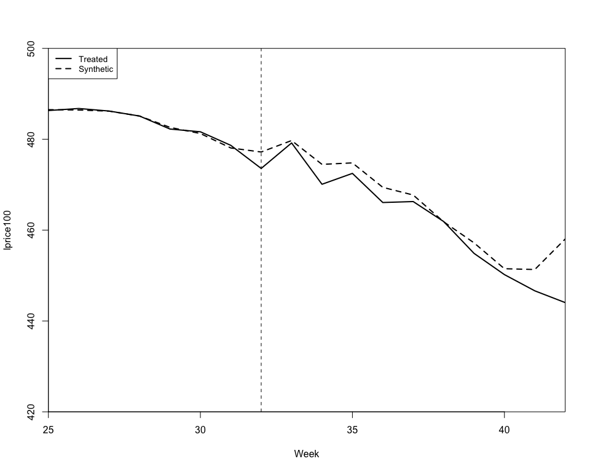

```r
path.plot(
  synth.res = synth.out,
  dataprep.res = dataprep.out,
  Ylab = "lprice100",
  Xlab = "Week",
  Legend.position = "topleft",
  Ylim = c(420, 500)
)
abline(v = 32, lty = 2)
```

График полностью совпадает с Fig.5(a) из статьи (для всех отелей). Видим эффект снижения цен в краткосрочном периоде

## Задание 2

Таблица весов наблюдений контрольной группы

```r
synth.tables <- synth.tab(dataprep.res = dataprep.out, synth.res = synth.out)
synth.tables["tab.w"]
```

```
## $tab.w
##    w.weights unit.names unit.numbers
## 5      0.000          5            5
## 6      0.391          6            6
## 7      0.001          7            7
## 8      0.001          8            8
## 9      0.142          9            9
## 10     0.000         10           10
## 11     0.000         11           11
## 12     0.362         12           12
## 13     0.000         13           13
## 14     0.000         14           14
## 15     0.000         15           15
## 16     0.000         16           16
## 17     0.000         17           17
## 18     0.099         18           18
## 19     0.000         19           19
## 20     0.001         20           20
## 21     0.000         21           21
## 22     0.000         22           22
```

Среднее значение контрольной группы Корсики

```r
mean(dataprep.out$Y1plot, na.rm = TRUE)
```

```
## [1] 470.6825
```

Среднее значение синтетической группы Корсики

```r
mean(dataprep.out$Y0plot %*% synth.out$solution.w)
```

```
## [1] 472.7433
```

Среднее значение контрольной группы меньше чем синтетической, что указывает на снижение цен в результате вступления в силу закона Макрона

## Задание 3

### Плацебо-тест по времени

Плацебо будет дано на 29 неделе

```r
placebo_week <- 29
dataprep.out <- dataprep(
  foo = data_task_2,
  predictors = c("lprice100", "bdays", "stars", "hot_size", "capacity",
                 "punteggio", "google_src", "num_days_start_booking"),
  predictors.op = "mean",
  dependent = "lprice100",
  unit.variable = "classification",
  unit.names.variable = "classification_char",
  time.variable = "week_src",
  treatment.identifier = 1,
  controls.identifier = unique(data_task_2$classification[data_task_2$classification != 1]),
  time.predictors.prior = 25:placebo_week,
  time.optimize.ssr = 25:placebo_week,
  time.plot = 25:42
)
synth.out <- synth(dataprep.out)
```

```
##
## X1, X0, Z1, Z0 all come directly from dataprep object.
##
##
## ****************
##  searching for synthetic control unit
##
##
## ****************
## ****************
## ****************
##
## MSPE (LOSS V): 0.2661173
##
## solution.v:
##  0.2957771 0.2429227 6.116e-07 0.1681345 0.1962505 2.339e-07 4.58e-08 0.09691432
##
## solution.w:
##  0.001450486 0.3080041 0.000847597 0.1902576 0.1305651 0.000402998 0.001485979 0.3035163 0.0002939828 0.0007265735 0.0002140391 8.37714e-05 0.0008114211 0.05820818 0.0005944477 0.0007690565 0.001492952 0.0002747172
```

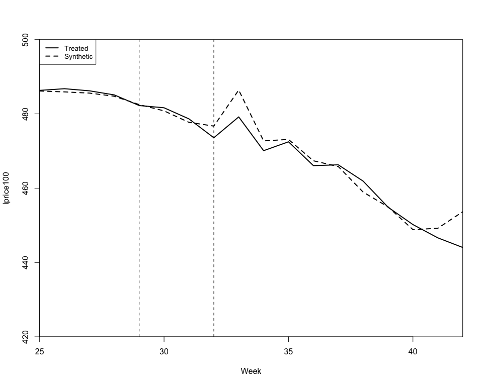

```r
path.plot(
  synth.res = synth.out,
  dataprep.res = dataprep.out,
  Ylab = "lprice100",
  Xlab = "Week",
  Legend.position = "topleft",
  Ylim = c(420, 500)
)
abline(v = placebo_week, lty = 2)
abline(v = 32, lty = 2)
```

Плацебо тест во времени нужен для проверки надежности модели и подтверждения причинно-следственной связи. Плацебо было дано на 29 неделе. Из графика видно, что в плацебо-периоде (с 29 по 32 недели) не зафиксированы отклонения в тренде, поэтому можно предположить, что зафиксированные изменения после 32 недели обусловлены действиями вмешательства, таким образом подтверждая причину и следствие.

Так как модель показывает устойчивое поведение, это подтверждает, что изменения обусловлены принятием закона Макрона во Франции на 32 неделе

## Задание 4

### Плацебо-тест в пространстве

```r
placebo_treatment_identifier <- 6
dataprep.out <- dataprep(
  foo = data_task_2,
  predictors = c("lprice100", "bdays", "stars", "hot_size", "capacity",
                 "punteggio", "google_src", "num_days_start_booking"),
  predictors.op = "mean",
  dependent = "lprice100",
  unit.variable = "classification",
  unit.names.variable = "classification_char",
  time.variable = "week_src",
  treatment.identifier = placebo_treatment_identifier,
  controls.identifier =
    unique(
      data_task_2$classification[
        data_task_2$classification != placebo_treatment_identifier & data_task_2$classification != 1
      ]
    ),
  time.predictors.prior = 25:32,
  time.optimize.ssr = 25:32,
  time.plot = 25:42
)
synth.out <- synth(dataprep.out)
```

```
##
## X1, X0, Z1, Z0 all come directly from dataprep object.
##
##
## ****************
##  searching for synthetic control unit
##
##
## ****************
## ****************
## ****************
##
## MSPE (LOSS V): 6.595386
##
## solution.v:
##  0.6821481 3.02e-08 0.01798089 0.1155562 0.08286112 0.07915437 0.01149706 0.01080221
##
## solution.w:
##  0.6436157 7.42518e-05 9.88873e-05 4.7015e-06 6.02375e-05 0.0005001155 0.0002124982 6.78266e-05 0.0001371481 2.11901e-05 1.33731e-05 0.3541014 0.0008709154 8.27779e-05 6.92448e-05 3.49512e-05 3.48467e-05
```

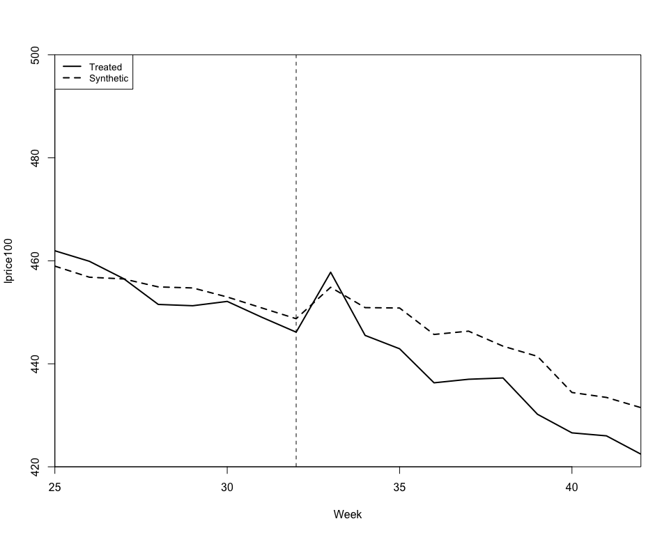

```r
path.plot(
  synth.res = synth.out,
  dataprep.res = dataprep.out,
  Ylab = "lprice100",
  Xlab = "Week",
  Legend.position = "topleft",
  Ylim = c(420, 500)
)
abline(v = 32, lty = 2)
```

Плацебо-тест “в пространстве” используется для проверки надежности, сопоставляя эффект вмешательства на тритмент-группу с потенциально похожими эффектами на некоторые контрольные группы, которые фактически не подвергались лечению. Это позволяет оценить насколько наблюдаемый эффект уникален для тритмент-группы.

### Численный критерий качества подгонки

Так как данные с 25 недели, то [1:7] это значения до принятия закона [25 неделя - 31 неделя], [8:18] это значения после принятия закона Макрона [32 неделя - 42 неделя]

```r
before <- sqrt(
  mean(
    (dataprep.out$Y1plot[1:7] - (dataprep.out$Y0plot[1:7,] %*% synth.out$solution.w))^2
  )
)
before
```

```
## [1] 2.561959
```

```r
after <- sqrt(
  mean(
    (dataprep.out$Y1plot[8:18] - (dataprep.out$Y0plot[8:18,] %*% synth.out$solution.w))^2
  )
)
after
```

```
## [1] 7.664263
```

```r
after / before
```

```
## [1] 2.991563
```

Можем предположить что пик цен в Сардинии на 33 неделе обусловлен резкой впадиной доступности отелей в Сардинии на 33 неделе.

## Задание 5

### Придумайте, как ещё можно было бы проверить качество оценок, полученных синтетическим контролем

Можно при построении синтетического контроля тритмент-группы не учитывать какое-нибудь наблюдение из контрольной группы и смотреть как изменится критерий подгонки. Так можно убедиться, что критерий подгонки не искажается из-за какого-то одного наблюдения в контрольной группе

```r
all_controls <- unique(data_task_2$classification[data_task_2$classification != 1])

#Критерии подгонки
errors_list <- vector("list", length(all_controls))
for (i in seq_along(all_controls)) {
  controls_without_one <- all_controls[-i]
  dataprep.out <- dataprep(
    foo = data_task_2,
    predictors = c("lprice100", "bdays", "stars", "hot_size", "capacity",
                   "punteggio", "google_src", "num_days_start_booking"),
    predictors.op = "mean",
    dependent = "lprice100",
    unit.variable = "classification",
    unit.names.variable = "classification_char",
    time.variable = "week_src",
    treatment.identifier = 1,
    controls.identifier = controls_without_one,
    time.predictors.prior = 25:32,
    time.optimize.ssr = 25:32,
    time.plot = 25:42
  )
  synth.out <- synth(dataprep.out)
  before <- sqrt(
    mean(
      (dataprep.out$Y1plot[1:7] - (dataprep.out$Y0plot[1:7,] %*% synth.out$solution.w))^2
    )
  )
  after <- sqrt(
    mean(
      (dataprep.out$Y1plot[8:18] - (dataprep.out$Y0plot[8:18,] %*% synth.out$solution.w))^2
    )
  )
  errors_list[i] <- after / before
}
```

[output not shown]

[output cut: 304 more lines]

[output not shown]

```r
print(errors_list)
```

```
## [[1]]
## [1] 4.81449
##
## [[2]]
## [1] 5.153552
##
## [[3]]
## [1] 7.316884
##
## [[4]]
## [1] 4.477991
##
## [[5]]
## [1] 3.037305
##
## [[6]]
## [1] 4.701912
##
## [[7]]
## [1] 3.152293
##
## [[8]]
## [1] 5.435885
##
## [[9]]
## [1] 3.058581
##
## [[10]]
## [1] 3.12277
##
## [[11]]
## [1] 4.708955
##
## [[12]]
## [1] 7.043622
##
## [[13]]
## [1] 4.119586
##
## [[14]]
## [1] 7.214187
##
## [[15]]
## [1] 4.842309
##
## [[16]]
## [1] 3.170928
##
## [[17]]
## [1] 6.07852
##
## [[18]]
## [1] 5.203082
```

Полученные результаты подтверждают данные из таблицы весов наблюдений контрольной группы. Таким образом выявлена чувствительность к выбору контрольных единиц. Что свидетельствует о не устойчивости модели. Это может быть следствием недостатка наблюдений в контрольной группе которые похожи на тритмент-группу

# Литература и смысл

Результаты этого исследования могут повлиять на формирование политических решений в других странах, рассматривающих подобные меры по регулированию рынков.

### Связанные вопросы

- Как ценовой паритет влияет на дистрибуцию цен на различных онлайн-платформах и традиционных каналах продаж?
- Какие долгосрочные эффекты или адаптационные процессы наблюдаются на рынках после введения регулирования против ценового паритета?
- Как изменения в политике онлайн-платформ влияют на поведение и стратегии других участников рынка, таких как клиенты и посредники?

### Почему важно

Маркетинговая литература подробно изучает влияние платформенной экономики на изменения стратегии дистрибуции и ценовую конкуренцию. Например, работы о “двусторонних рынках” и влиянии платформ на традиционные рынки могут дать дополнительный контекст.

Jean-Charles Rochet and Jean Tirole (2003) “Platform Competition in Two-Sided Markets”